# Modeling Concrete Strength

Matt Richey

September 29, 2016

# Introduction

We look at modeling a data set for concrete strength using both linear regression and KNN.

Load the libraries, including FNN for the knn.reg.

```r
library(ggplot2)
library(dplyr)
library(tidyr)
library(FNN)
```

Read the data

```r
concrete.df<-read.csv("concrete.csv")
```

```r
names(concrete.df)
```

```
##  [1] "No"         "Cement"     "Slag"       "FlyAsh"     "Water"
##  [6] "SP"         "CoarseAggr" "FineAggr"   "SLUMP"      "FLOW"
## [11] "Strength"
```

SLUMP, FLOW, and Strength are all potential response variables, only keep Strength.

No is just a row number.

```r
concrete.df <- concrete.df %>%
  select(-SLUMP,-FLOW,-No)
```

Take a look at remaining combinations.

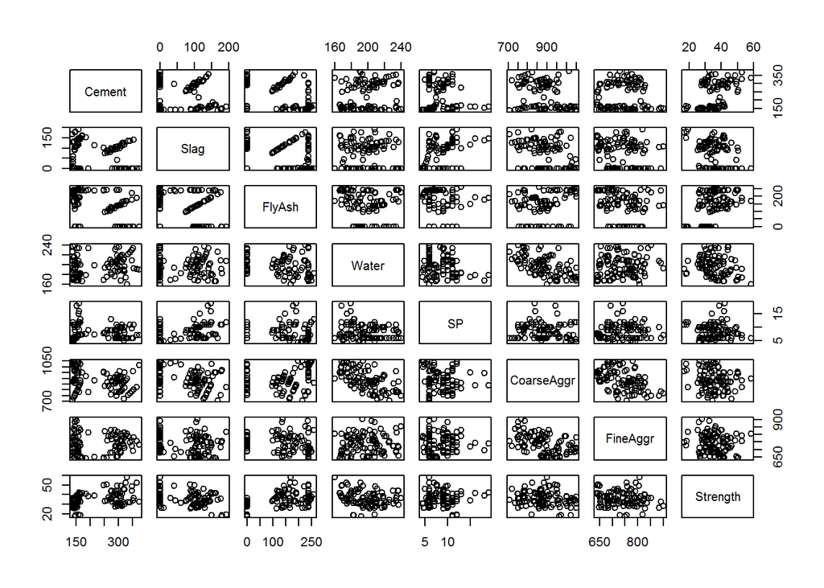

```r
pairs(concrete.df)
```

There appears to be a potential for a relationship between Cement, Slag and Strength.

Quick Plots

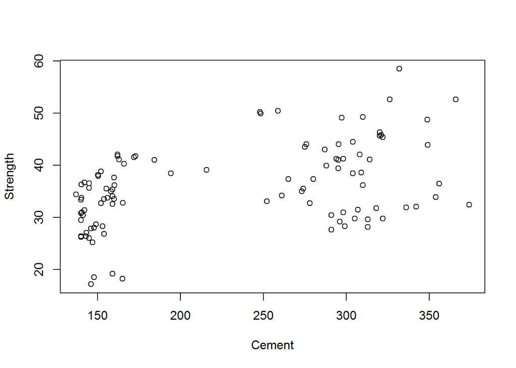

```r
with(concrete.df,plot(Cement,Strength))
```

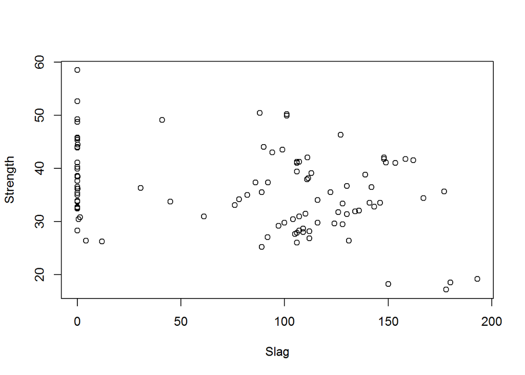

```r
with(concrete.df,plot(Slag,Strength))
```

Look a little closer at Slag. There are a lot of zero values.

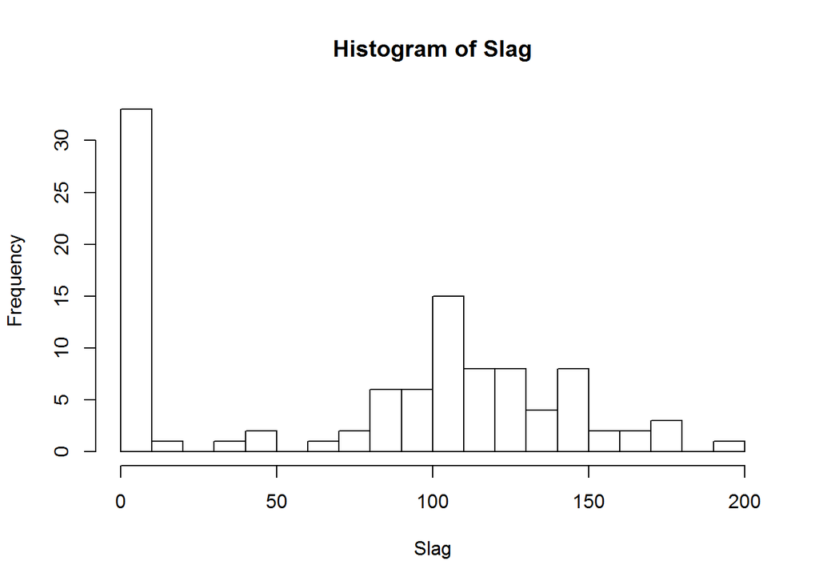

```r
with(concrete.df,hist(Slag,breaks=25))
```

Create a qualitative predictor from Slag

```r
concrete.df<-mutate(concrete.df,LowSlag=Slag==0)
```

## Model Strength with Concrete and LowSlag/Slag

Look at the combination of the quantitative and qualitative predictors

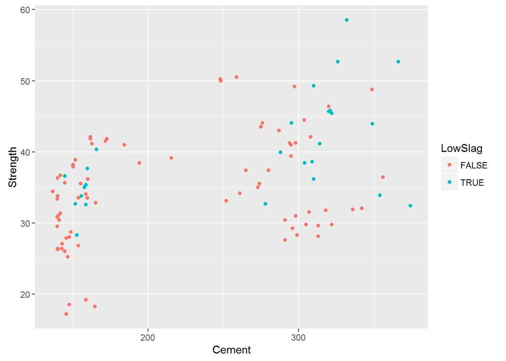

```r
ggplot(concrete.df,aes(Cement,Strength,color=LowSlag))+
  geom_point()
```

A basic linear model with two predictors

```r
mod1<-lm(Strength~Cement+LowSlag,data=concrete.df)
```

The model summary

```r
summary(mod1)
```

```
##
## Call:
## lm(formula = Strength ~ Cement + LowSlag, data = concrete.df)
##
## Residuals:
##      Min       1Q   Median       3Q      Max
## -14.6442  -5.3104   0.2519   4.6448  15.7531
##
## Coefficients:
##              Estimate Std. Error t value Pr(>|t|)
## (Intercept) 26.131536   2.110943  12.379  < 2e-16 ***
## Cement       0.039059   0.008977   4.351 3.27e-05 ***
## LowSlagTRUE  3.677669   1.622104   2.267   0.0255 *
## ---
## Signif. codes:  0 '***' 0.001 '**' 0.01 '*' 0.05 '.' 0.1 ' ' 1
##
## Residual standard error: 6.911 on 100 degrees of freedom
## Multiple R-squared:  0.2378, Adjusted R-squared:  0.2226
## F-statistic:  15.6 on 2 and 100 DF,  p-value: 1.265e-06
```

How do we read this??

- Increasing Cement increases the Strength
- LowSlag==TRUE also appears to increase the strength
- Both these predictors are statistically significant

Now make predictions on the training set

```r
pred<-predict(mod1)
concrete.df$pred<-pred
```

The visual inspection of predictions

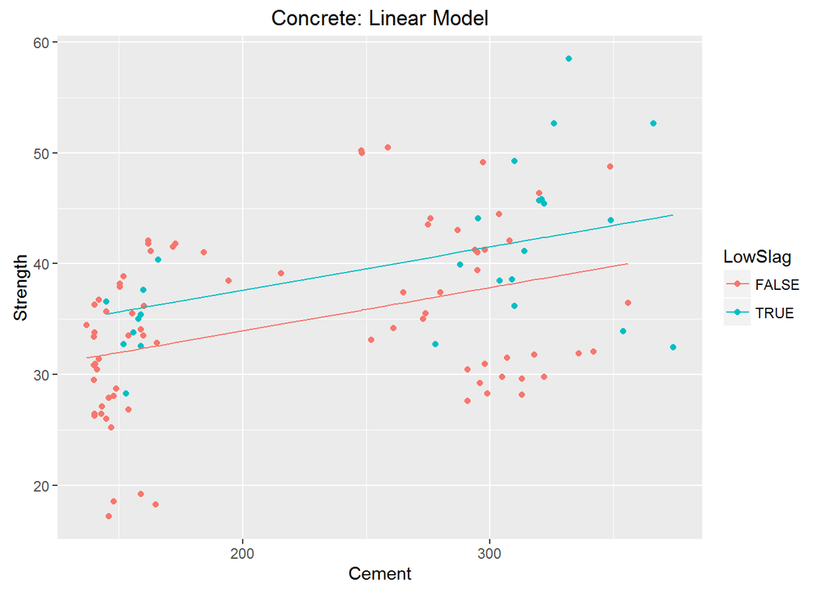

```r
ggplot(concrete.df,aes(Cement,Strength,color=LowSlag))+
  geom_point()+
  geom_line(aes(Cement,pred))+
  ggtitle("Concrete: Linear Model")
```

Now add an interaction between Concrete and LowSlag

```r
mod2<-lm(Strength~Cement+LowSlag+Cement:LowSlag,data=concrete.df)
summary(mod2)
```

```
##
## Call:
## lm(formula = Strength ~ Cement + LowSlag + Cement:LowSlag, data = concrete.df)
##
## Residuals:
##      Min       1Q   Median       3Q      Max
## -14.9743  -5.6305   0.1967   4.5978  15.0028
##
## Coefficients:
##                    Estimate Std. Error t value Pr(>|t|)
## (Intercept)        27.12930    2.46046  11.026  < 2e-16 ***
## Cement              0.03449    0.01068   3.228  0.00169 **
## LowSlagTRUE        -0.26684    5.23013  -0.051  0.95941
## Cement:LowSlagTRUE  0.01571    0.01980   0.793  0.42941
## ---
## Signif. codes:  0 '***' 0.001 '**' 0.01 '*' 0.05 '.' 0.1 ' ' 1
##
## Residual standard error: 6.924 on 99 degrees of freedom
## Multiple R-squared:  0.2427, Adjusted R-squared:  0.2197
## F-statistic: 10.57 on 3 and 99 DF,  p-value: 4.297e-06
```

The Cement:LowSlagTRUE coefficient is positive (but not significant). This is saying there is very weak evidence that in the presence of LowSlag, that the Cement effect is even stronger.

Plot this

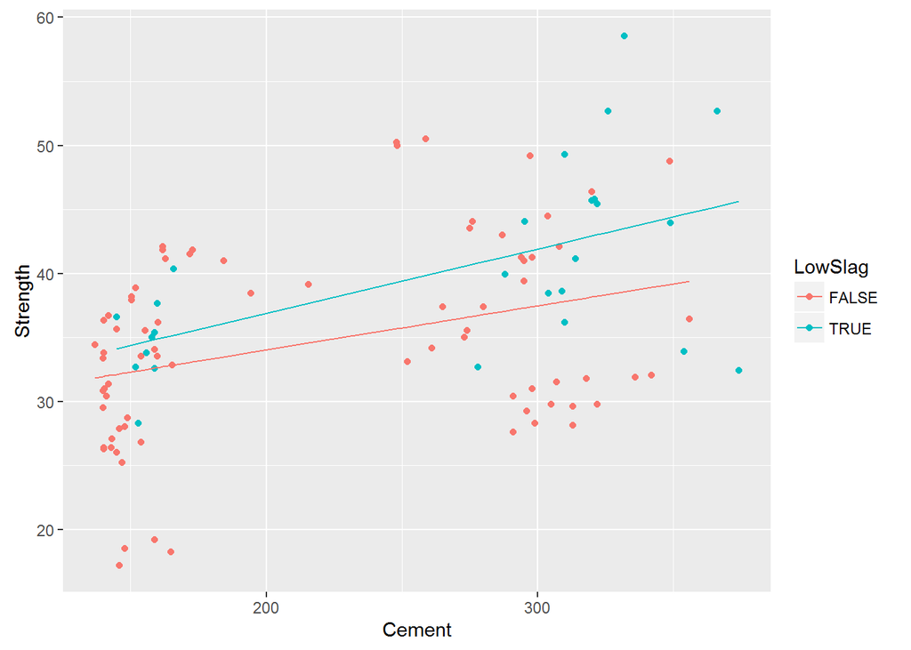

```r
concrete.df$pred<-predict(mod2)
ggplot(concrete.df,aes(Cement,Strength,color=LowSlag))+
  geom_point()+
  geom_line(aes(Cement,pred))
```

Using geom_smooth(method=lm) gives the same graph.

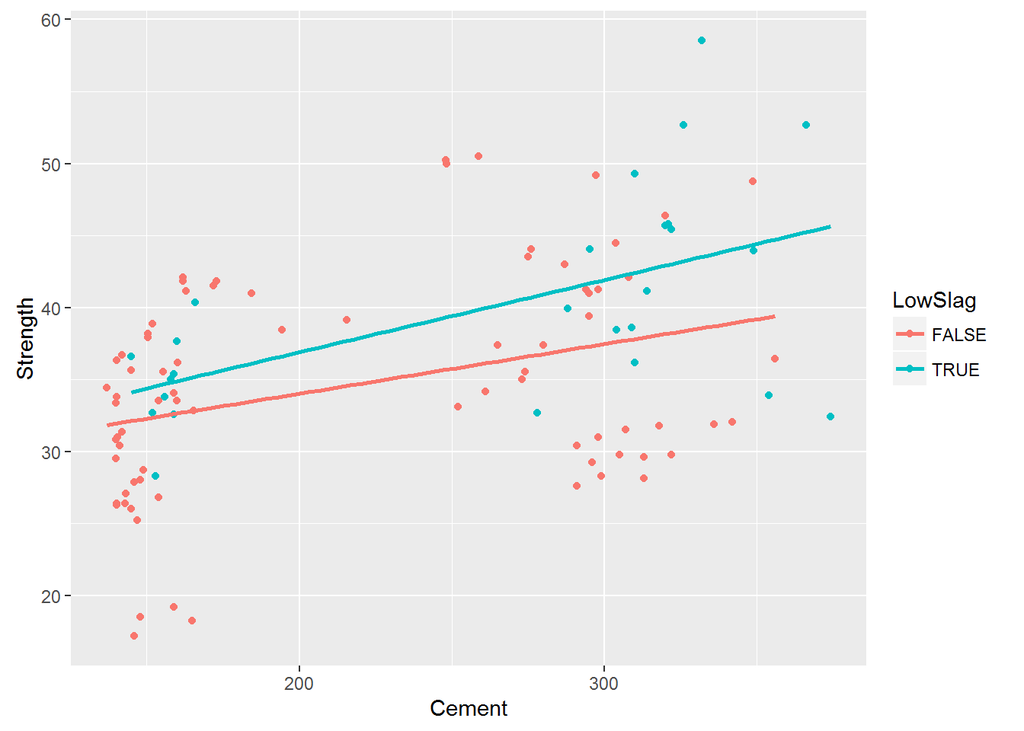

```r
ggplot(concrete.df,aes(Cement,Strength,color=LowSlag))+
  geom_point()+
  geom_smooth(method=lm,se=F)
```

# Prediction

Let’s focus on just Cement

```r
mod0<-lm(Strength~Cement,data=concrete.df)
concrete.df$pred<-predict(mod0)
summary(mod0)
```

```
##
## Call:
## lm(formula = Strength ~ Cement, data = concrete.df)
##
## Residuals:
##      Min       1Q   Median       3Q      Max
## -15.1335  -5.3126   0.8321   5.1553  17.9680
##
## Coefficients:
##              Estimate Std. Error t value Pr(>|t|)
## (Intercept) 25.856758   2.150223  12.025  < 2e-16 ***
## Cement       0.044293   0.008851   5.004 2.38e-06 ***
## ---
## Signif. codes:  0 '***' 0.001 '**' 0.01 '*' 0.05 '.' 0.1 ' ' 1
##
## Residual standard error: 7.051 on 101 degrees of freedom
## Multiple R-squared:  0.1987, Adjusted R-squared:  0.1907
## F-statistic: 25.04 on 1 and 101 DF,  p-value: 2.379e-06
```

The plot

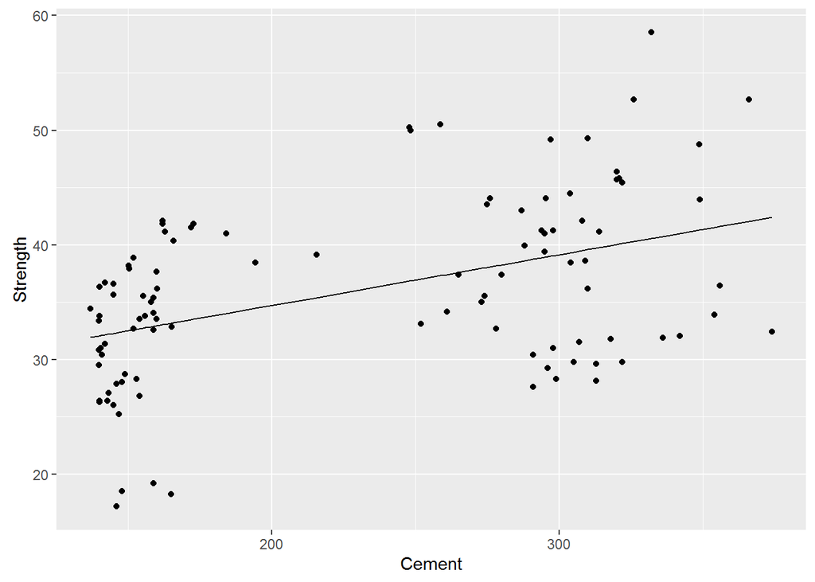

```r
ggplot(concrete.df,aes(Cement,Strength))+
  geom_point()+
  geom_line(aes(Cement,pred))
```

Let’s do some a “Feature expansion” : add quadratic term in Cement.

```r
mod2<-lm(Strength~Cement+I(Cement^2),data=concrete.df)
concrete.df$pred<-predict(mod2)
```

And the plot…

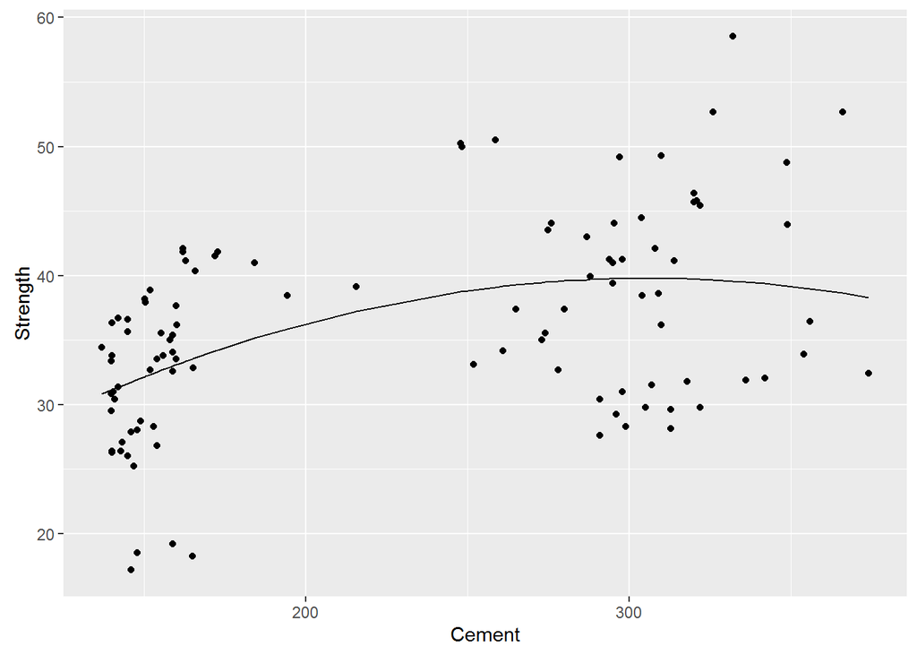

```r
ggplot(concrete.df,aes(Cement,Strength))+
  geom_point()+
  geom_line(aes(Cement,pred))
```

This is same adding a new predictor equal to Cement^2

```r
concrete.df<-concrete.df %>%
  mutate(Cement2=Cement^2)
mod2x<-lm(Strength~Cement+Cement2,data=concrete.df)
```

The summaries are evidence that they are the same.

```r
summary(mod2x)
```

```
##
## Call:
## lm(formula = Strength ~ Cement + Cement2, data = concrete.df)
##
## Residuals:
##      Min       1Q   Median       3Q      Max
## -15.2912  -4.9258   0.4111   4.8458  18.9537
##
## Coefficients:
##               Estimate Std. Error t value Pr(>|t|)
## (Intercept) 10.2823890 10.0705502   1.021   0.3097
## Cement       0.1931789  0.0944936   2.044   0.0435 *
## Cement2     -0.0003161  0.0001997  -1.582   0.1167
## ---
## Signif. codes:  0 '***' 0.001 '**' 0.01 '*' 0.05 '.' 0.1 ' ' 1
##
## Residual standard error: 6.999 on 100 degrees of freedom
## Multiple R-squared:  0.2182, Adjusted R-squared:  0.2026
## F-statistic: 13.96 on 2 and 100 DF,  p-value: 4.503e-06
```

```r
summary(mod2)
```

```
##
## Call:
## lm(formula = Strength ~ Cement + I(Cement^2), data = concrete.df)
##
## Residuals:
##      Min       1Q   Median       3Q      Max
## -15.2912  -4.9258   0.4111   4.8458  18.9537
##
## Coefficients:
##               Estimate Std. Error t value Pr(>|t|)
## (Intercept) 10.2823890 10.0705502   1.021   0.3097
## Cement       0.1931789  0.0944936   2.044   0.0435 *
## I(Cement^2) -0.0003161  0.0001997  -1.582   0.1167
## ---
## Signif. codes:  0 '***' 0.001 '**' 0.01 '*' 0.05 '.' 0.1 ' ' 1
##
## Residual standard error: 6.999 on 100 degrees of freedom
## Multiple R-squared:  0.2182, Adjusted R-squared:  0.2026
## F-statistic: 13.96 on 2 and 100 DF,  p-value: 4.503e-06
```

More feature expansion: cubic term

```r
mod3<-lm(Strength~Cement+I(Cement^2)+I(Cement^3),data=concrete.df)
summary(mod3)
```

```
##
## Call:
## lm(formula = Strength ~ Cement + I(Cement^2) + I(Cement^3), data = concrete.df)
##
## Residuals:
##      Min       1Q   Median       3Q      Max
## -17.0929  -4.5361   0.5011   5.0736  19.4183
##
## Coefficients:
##               Estimate Std. Error t value Pr(>|t|)
## (Intercept) -7.922e+01  4.550e+01  -1.741   0.0848 .
## Cement       1.380e+00  5.962e-01   2.315   0.0227 *
## I(Cement^2) -5.216e-03  2.439e-03  -2.139   0.0349 *
## I(Cement^3)  6.423e-06  3.187e-06   2.016   0.0465 *
## ---
## Signif. codes:  0 '***' 0.001 '**' 0.01 '*' 0.05 '.' 0.1 ' ' 1
##
## Residual standard error: 6.894 on 99 degrees of freedom
## Multiple R-squared:  0.2491, Adjusted R-squared:  0.2263
## F-statistic: 10.95 on 3 and 99 DF,  p-value: 2.857e-06
```

```r
concrete.df$pred<-predict(mod3)
```

The plot of the cubic fit.

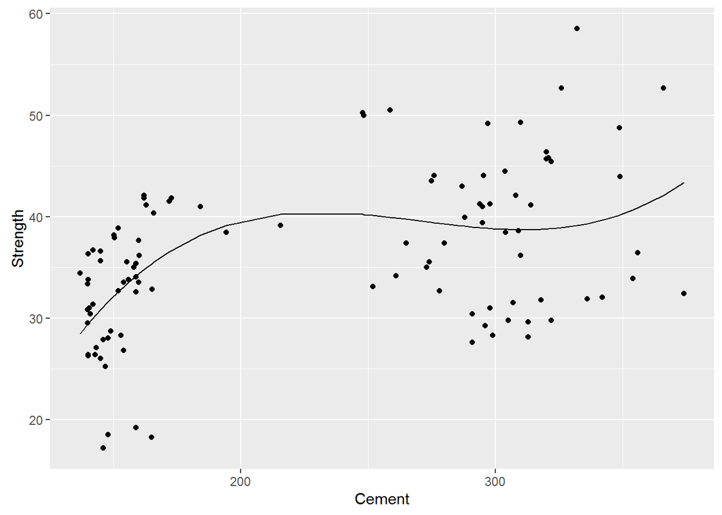

```r
ggplot(concrete.df,aes(Cement,Strength))+
  geom_point()+
  geom_line(aes(Cement,pred))
```

More feature expansion: cubic term: quartic term

```r
mod4<-lm(Strength~Cement+I(Cement^2)+I(Cement^3)+I(Cement^4),
         data=concrete.df)
summary(mod4)
```

```
##
## Call:
## lm(formula = Strength ~ Cement + I(Cement^2) + I(Cement^3) +
##     I(Cement^4), data = concrete.df)
##
## Residuals:
##      Min       1Q   Median       3Q      Max
## -17.4226  -4.5197   0.5488   4.9802  19.0134
##
## Coefficients:
##               Estimate Std. Error t value Pr(>|t|)
## (Intercept) -1.460e+02  1.567e+02  -0.932    0.354
## Cement       2.581e+00  2.760e+00   0.935    0.352
## I(Cement^2) -1.299e-02  1.761e-02  -0.738    0.463
## I(Cement^3)  2.793e-05  4.835e-05   0.578    0.565
## I(Cement^4) -2.152e-08  4.828e-08  -0.446    0.657
##
## Residual standard error: 6.923 on 98 degrees of freedom
## Multiple R-squared:  0.2506, Adjusted R-squared:   0.22
## F-statistic: 8.192 on 4 and 98 DF,  p-value: 9.651e-06
```

Notice that none of the terms are significant now

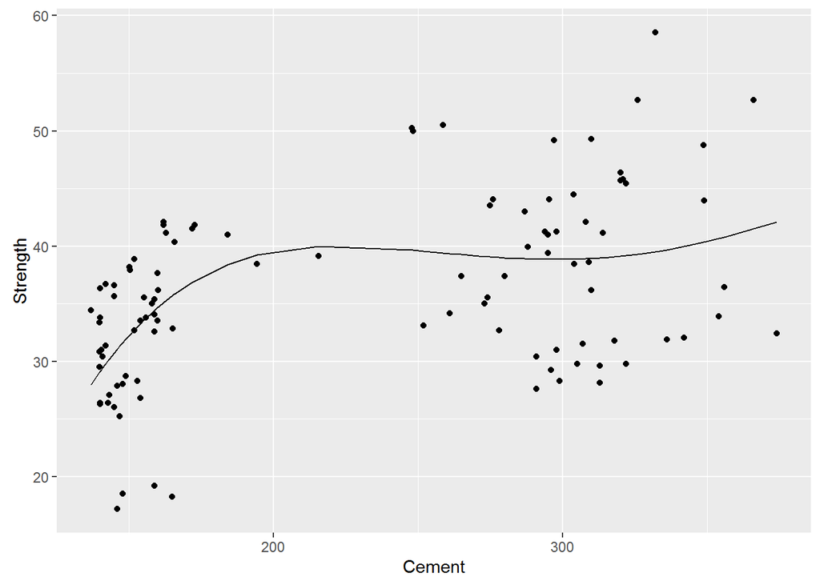

```r
concrete.df$pred<-predict(mod4)
ggplot(concrete.df,aes(Cement,Strength))+
  geom_point()+
  geom_line(aes(Cement,pred))
```

More feature expansion: Add *any number of powers of Cement

Fix the degree

```r
maxDeg<-4
```

Begin with a starter string and iteratively add more terms.

```r
formStr<-"Strength~Cement" #starter string
for(d in 2:maxDeg){
  formStr<-sprintf("%s+I(Cement^%s)",formStr,d)
}
formStr
```

```
## [1] "Strength~Cement+I(Cement^2)+I(Cement^3)+I(Cement^4)"
```

Convert string to formula using function **formula**

```r
modMax<-lm(formula(formStr),
         data=concrete.df)
summary(modMax)
```

```
##
## Call:
## lm(formula = formula(formStr), data = concrete.df)
##
## Residuals:
##      Min       1Q   Median       3Q      Max
## -17.4226  -4.5197   0.5488   4.9802  19.0134
##
## Coefficients:
##               Estimate Std. Error t value Pr(>|t|)
## (Intercept) -1.460e+02  1.567e+02  -0.932    0.354
## Cement       2.581e+00  2.760e+00   0.935    0.352
## I(Cement^2) -1.299e-02  1.761e-02  -0.738    0.463
## I(Cement^3)  2.793e-05  4.835e-05   0.578    0.565
## I(Cement^4) -2.152e-08  4.828e-08  -0.446    0.657
##
## Residual standard error: 6.923 on 98 degrees of freedom
## Multiple R-squared:  0.2506, Adjusted R-squared:   0.22
## F-statistic: 8.192 on 4 and 98 DF,  p-value: 9.651e-06
```

Now we can easily model using any degree we want.

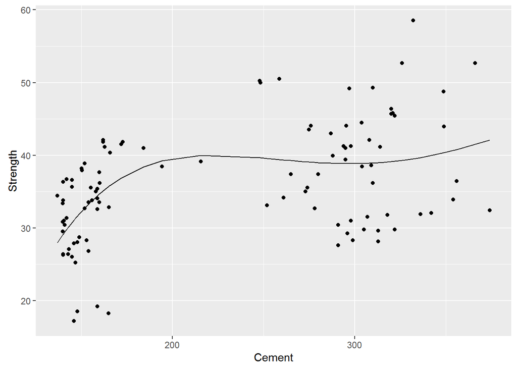

```r
concrete.df$pred.lm<-predict(modMax)
ggplot(concrete.df,aes(Cement,Strength))+
  geom_point()+
  geom_line(aes(Cement,pred.lm))
```

Natural question: * Which degree is best? Use a train/test approach to find optimal value.

## Nearest Neighbors: KNN for regression

Use library(FNN) and check out ?knn.reg

For knn.reg, need to use matrices again.

Here we go bulding matrices of the proper dimensions from a data frame

The data

```r
cement<-with(concrete.df,Cement)
resp<-with(concrete.df,Strength)
```

The dimensions

```r
dim(cement)<-c(nrow(concrete.df),1)
dim(resp)<-c(nrow(concrete.df),1)
```

Set the number of neighbors

```r
kval<-10
```

Use original data as test data, for comparison to linear regression approach

```r
mod.knn<-knn.reg(cement,NULL,resp,k=kval)
```

Here are the predictions

```r
concrete.df$pred.knn<-mod.knn$pred
```

And a plot…

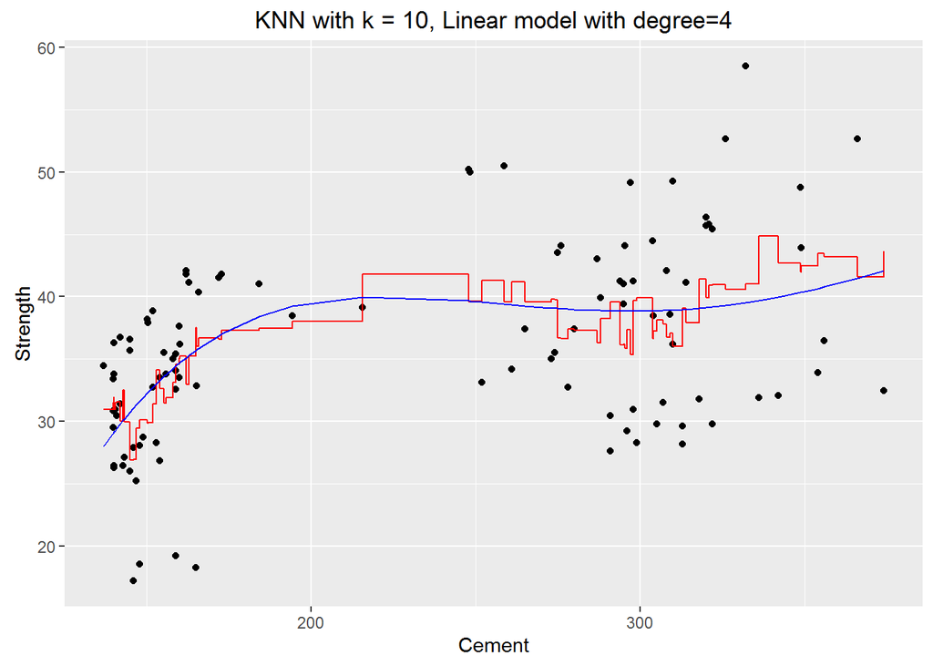

```r
ggplot(data=concrete.df)+
  geom_point(aes(Cement,Strength))+
  geom_step(aes(Cement,pred.knn),color="red")+
  geom_line(aes(Cement,pred.lm),color="blue")+
  ggtitle(sprintf("KNN with k = %s, Linear model with degree=%s",kval,maxDeg))
```

Build KNN.reg on an arbitrary test data set. Here I’ll use equally spaced values over the range of the Cement values.

```r
nn<-75
rr<-with(concrete.df,range(Cement))
test<-seq(rr[1],rr[2],len=nn)
dim(test)<-c(nn,1)
```

Now use knn.reg with the test data set.

```r
mod.knn<-knn.reg(cement,test,resp,k=kval)
```

Here’s a way to combine the train and test data in a single plot.

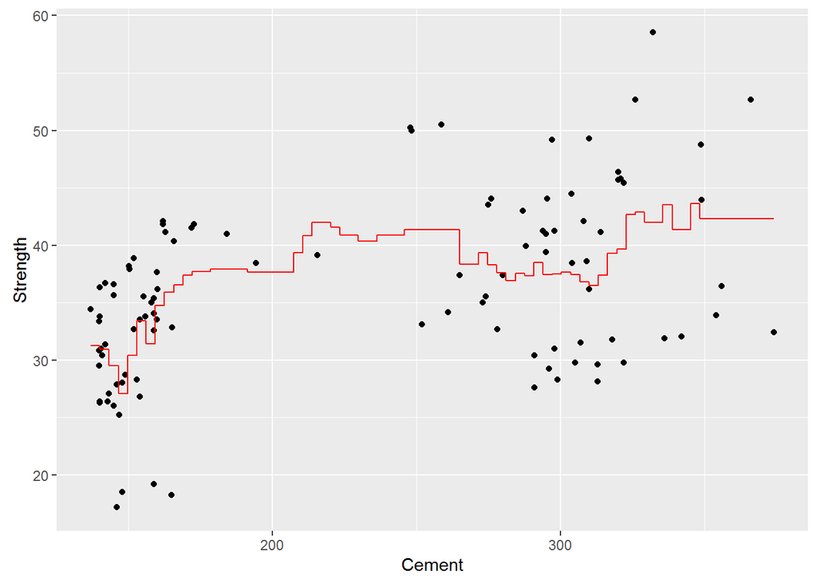

```r
ggplot()+
  geom_point(data=concrete.df,aes(Cement,Strength))+
  geom_step(data=NULL,aes(x=test,y=mod.knn$pred),color="red")
```

# Assignment

Comparison of Linear Models and KNN as a predictor of Concrete Strength.

- Stage 1: Single predictor: Cement –> Strength Which one is better…knn (kval=?) or lm (maxDeg=?)
- Stage 2: Two predictors: Cement+Slag (continuous) –> Strength Same question
- Stage 3: Add an additional quantitative predictor. Does this improve the prediction power of either method?

For your analysis, use multiple random train+test combinations to evaluate your MSE. Each time, use half the data used to train, the other half used to test.

## Assignment Response

Single Predictor:

```r
iterations <- 10
nn <- nrow(cement)
test <- sample(1:nn, nn/2, rep = F)
train <- setdiff(1:nn, test)

train.df <- concrete.df[train,]
test.df <- concrete.df[test,]

mse <- matrix(nrow = iterations, ncol = 2) # need 2 cols, one for testing the LM, one for the KNN
# we can only do it nn / 2 times since that is the number of values in the set and k can't be higher than that
for (i in 1:iterations) {
    # make lm
    formStr <- "Strength~Cement" #starter string
    for(d in 1:i){
        formStr <- sprintf("%s+I(Cement^%s)", formStr, d) # build the formula of degree i
    }
    linearModel <- lm(formula(formStr), data = train.df) # train the lm
    # test the lm
    #testResults <- predict(linearModel, newdata = train.df) # test the lm
    #mse[i, 1] <- with(test, tmean((strength - testResults)^2)) # put the MSE in the appropriate row, first column
}
```